# 5th_week_insik_cho (1)

```python
import warnings
warnings.filterwarnings(action='ignore')
```

```python
import sys
import sklearn
import numpy as np
import os

np.random.seed(42)

%matplotlib inline
import matplotlib as mpl
import matplotlib.pyplot as plt
mpl.rc('axes', labelsize = 14)
mpl.rc('xtick', labelsize = 12)
mpl.rc('ytick', labelsize = 12)

PROJECT_ROOT_DIR = "."
CHAPTER_ID = "unsupervised_learning"
IMAGES_PATH = os.path.join(PROJECT_ROOT_DIR, "images", CHAPTER_ID)
os.makedirs(IMAGES_PATH, exist_ok=True)

def save_fig(fig_id, tight_layout=True, fig_extension="png", resolution=300):
    path = os.path.join(IMAGES_PATH, fig_id + "." + fig_extension)
    print("Saving figure", fig_id)
    if tight_layout:
        plt.tight_layout()
    plt.savefig(path, format=fig_extension, dpi=resolution)
```

## classification vs clustering

```python
from sklearn.datasets import load_iris
```

```python
data = load_iris()
print(data.DESCR)
```

```
.. _iris_dataset:

Iris plants dataset
--------------------

**Data Set Characteristics:**

    :Number of Instances: 150 (50 in each of three classes)
    :Number of Attributes: 4 numeric, predictive attributes and the class
    :Attribute Information:
        - sepal length in cm
        - sepal width in cm
        - petal length in cm
        - petal width in cm
        - class:
                - Iris-Setosa
                - Iris-Versicolour
                - Iris-Virginica

    :Summary Statistics:

    ============== ==== ==== ======= ===== ====================
                    Min  Max   Mean    SD   Class Correlation
    ============== ==== ==== ======= ===== ====================
    sepal length:   4.3  7.9   5.84   0.83    0.7826
    sepal width:    2.0  4.4   3.05   0.43   -0.4194
    petal length:   1.0  6.9   3.76   1.76    0.9490  (high!)
    petal width:    0.1  2.5   1.20   0.76    0.9565  (high!)
    ============== ==== ==== ======= ===== ====================

    :Missing Attribute Values: None
    :Class Distribution: 33.3% for each of 3 classes.
    :Creator: R.A. Fisher
    :Donor: Michael Marshall (MARSHALL%PLU@io.arc.nasa.gov)
    :Date: July, 1988

The famous Iris database, first used by Sir R.A. Fisher. The dataset is taken
from Fisher's paper. Note that it's the same as in R, but not as in the UCI
Machine Learning Repository, which has two wrong data points.

```

[output cut: 8 more lines]

```

   - Fisher, R.A. "The use of multiple measurements in taxonomic problems"
     Annual Eugenics, 7, Part II, 179-188 (1936); also in "Contributions to
     Mathematical Statistics" (John Wiley, NY, 1950).
   - Duda, R.O., & Hart, P.E. (1973) Pattern Classification and Scene Analysis.
     (Q327.D83) John Wiley & Sons.  ISBN 0-471-22361-1.  See page 218.
   - Dasarathy, B.V. (1980) "Nosing Around the Neighborhood: A New System
     Structure and Classification Rule for Recognition in Partially Exposed
     Environments".  IEEE Transactions on Pattern Analysis and Machine
     Intelligence, Vol. PAMI-2, No. 1, 67-71.
   - Gates, G.W. (1972) "The Reduced Nearest Neighbor Rule".  IEEE Transactions
     on Information Theory, May 1972, 431-433.
   - See also: 1988 MLC Proceedings, 54-64.  Cheeseman et al"s AUTOCLASS II
     conceptual clustering system finds 3 classes in the data.
   - Many, many more ...
```

```python
X = data.data
y = data.target
data.target_names
```

```
array(['setosa', 'versicolor', 'virginica'], dtype='<U10')
```

```
Saving figure classification_vs_clustering_plot
```

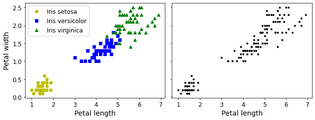

```python
plt.figure(figsize = (9,3.5))

plt.subplot(121)
plt.plot(X[y==0, 2], X[y==0, 3], "yo", label="Iris setosa")
plt.plot(X[y==1, 2], X[y==1, 3], "bs", label="Iris versicolor")
plt.plot(X[y==2, 2], X[y==2, 3], "g^", label="Iris virginica")
plt.xlabel("Petal length", fontsize=14)
plt.ylabel("Petal width", fontsize=14)
plt.legend(fontsize=12)

plt.subplot(122)
plt.scatter(X[:, 2], X[:, 3], c="k", marker=".")
plt.xlabel("Petal length", fontsize=14)
plt.tick_params(labelleft=False)

save_fig("classification_vs_clustering_plot")
plt.show()

##left one is clustered, righte one is not
```

좌측과 같이 label이 존재할 때 classification을 사용. 우측과 같이 label이 존재하지 않으면 clustering 사용

gaussian mixture model을 통하여 =우측의 데이터를 cluster 해보자

```python
from sklearn.mixture import GaussianMixture
```

```python
y_pred = GaussianMixture(n_components = 3, random_state = 42).fit(X).predict(X)
mapping = np.array([2,0,1])
y_pred = np.array([mapping[cluster_id] for cluster_id in y_pred])
```

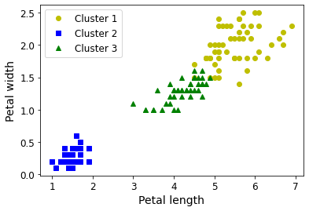

```python
plt.plot(X[y_pred==0, 2], X[y_pred==0, 3], "yo", label="Cluster 1")
plt.plot(X[y_pred==1, 2], X[y_pred==1, 3], "bs", label="Cluster 2")
plt.plot(X[y_pred==2, 2], X[y_pred==2, 3], "g^", label="Cluster 3")
plt.xlabel("Petal length", fontsize=14)
plt.ylabel("Petal width", fontsize=14)
plt.legend(loc="upper left", fontsize=12)
plt.show()
```

```python
np.sum(y_pred ==y)
```

```
0
```

```python
np.sum(y_pred ==y)/ len(y_pred)
```

```
0.0
```

# k- means

KMeans(n_clusters, init, n_init, algorithm)

n_clusters : 분류할 클러스터의 수

init = 초기점을 정하는 방법. default = k-means++

n_init = 초기점을 바꿔가면서 반복할 때, 몇번 반복할 지

algorithm = k-means에 적용할 알고리즘.full과 elkan이 있으며 full이 우리가 배운 EM algorithm이고, elkan이 단축해서 빠르게 하는 방식. default는 elkan 이다.

```python
KMeans()
```

```
KMeans(algorithm='auto', copy_x=True, init='k-means++', max_iter=300,
       n_clusters=8, n_init=10, n_jobs=None, precompute_distances='auto',
       random_state=None, tol=0.0001, verbose=0)
```

```python
# 개체생성
from sklearn.datasets import make_blobs
```

```python
blob_centers = np.array(
    [[ 0.2,  2.3],
     [-1.5 ,  2.3],
     [-2.8,  1.8],
     [-2.8,  2.8],
     [-2.8,  1.3]])
blob_std = np.array([0.4, 0.3, 0.1, 0.1, 0.1])
```

```python
X , y = make_blobs(n_samples = 2000, centers = blob_centers,
                  cluster_std = blob_std, random_state = 7)
```

```
Saving figure blobs_plot
```

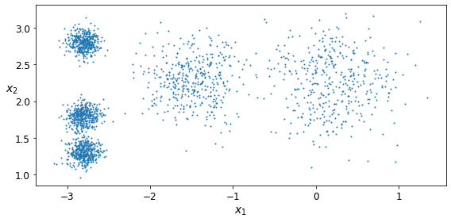

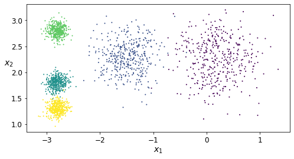

```python
def plot_clusters(X, y=None):  ## 위에서 만든 data를 그리는데, cluster가 목적이므로 y = None 지정)
    plt.scatter(X[:,0], X[:,1],c = y, s = 1)
    plt.xlabel("$x_1$", fontsize=14)
    plt.ylabel("$x_2$", fontsize=14, rotation=0)


plt.figure(figsize=(8, 4))
plot_clusters(X)
save_fig("blobs_plot")

plt.figure(figsize=(8, 4))
plot_clusters(X, y = y)
plt.show()
```

## Fit and predict

make_blobs 로 만든 데이터셋에다가 K-means clsuter를 해서 아래와 같은 분류를 해보자.

```python
from sklearn.cluster import KMeans
```

```python
k = 5
kmeans = KMeans(n_clusters = k, random_state = 42)
y_pred = kmeans.fit_predict(X)
```

```python
y_pred
```

```
array([4, 1, 0, ..., 3, 0, 1], dtype=int32)
```

각 데이터마다 cluster가 배정됨

```python
kmeans.cluster_centers_
```

```
array([[ 0.20876306,  2.25551336],
       [-2.80389616,  1.80117999],
       [-1.46679593,  2.28585348],
       [-2.79290307,  2.79641063],
       [-2.80037642,  1.30082566]])
```

기존의 label도 그대로 남아있음

```python
kmeans.labels_
```

```
array([4, 1, 0, ..., 3, 0, 1], dtype=int32)
```

kmeans 함수를 이용하여 추가적으로 데이터 분류하는것도 물론 가능

```python
X_new = np.array([[0, 2], [3, 2], [-3, 3], [-3, 2.5]])
kmeans.predict(X_new)
```

```
array([0, 0, 3, 3], dtype=int32)
```

## Decision boundary

항상 하던데로 decision boundary를 그리자. 이를 Voronni diagram이라고 함(그래?)

```python
def plot_data(X):
    plt.plot(X[:, 0], X[:, 1], 'k.', markersize=2)

def plot_centroids(centroids, weights=None, circle_color='w', cross_color='k'):
    if weights is not None:
        centroids = centroids[weights > weights.max() / 10]
    plt.scatter(centroids[:, 0], centroids[:, 1],
                marker='o', s=30, linewidths=8,
                color=circle_color, zorder=10, alpha=0.9)
    plt.scatter(centroids[:, 0], centroids[:, 1],
                marker='x', s=50, linewidths=50,
                color=cross_color, zorder=11, alpha=1)

def plot_decision_boundaries(clusterer, X, resolution=1000, show_centroids=True,
                             show_xlabels=True, show_ylabels=True):
    mins = X.min(axis=0) - 0.1
    maxs = X.max(axis=0) + 0.1
    xx, yy = np.meshgrid(np.linspace(mins[0], maxs[0], resolution),
                         np.linspace(mins[1], maxs[1], resolution))
    Z = clusterer.predict(np.c_[xx.ravel(), yy.ravel()])
    Z = Z.reshape(xx.shape)
#contour = 등고선
    plt.contourf(Z, extent=(mins[0], maxs[0], mins[1], maxs[1]),
                cmap="Pastel2")
    plt.contour(Z, extent=(mins[0], maxs[0], mins[1], maxs[1]),
                linewidths=1, colors='k')
    plot_data(X)
    if show_centroids:
        plot_centroids(clusterer.cluster_centers_)

    if show_xlabels:
        plt.xlabel("$x_1$", fontsize=14)
    else:
        plt.tick_params(labelbottom=False)
    if show_ylabels:
        plt.ylabel("$x_2$", fontsize=14, rotation=0)
    else:
        plt.tick_params(labelleft=False)
```

```
Saving figure voronoi_plot
```

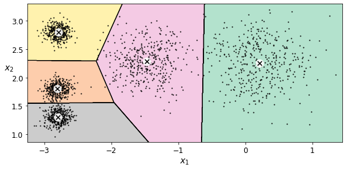

```python
plt.figure(figsize = (8,4))
plot_decision_boundaries(kmeans ,X)
save_fig("voronoi_plot")
plt.show()
```

## hard clustering vs soft clustring

hard cluster는 각 경우마다 가장 가까운 cluster는 찾는거지만, soft cluster은 각각의 클러스터에 대한 거리를 모두 측정하여 비교. => cluster마다 점수를 주어 비교?

```python
X_new = np.array([[0, 2], [3, 2], [-3, 3], [-3, 2.5]])
print(kmeans.predict(X_new))
print(kmeans.transform(X_new))
```

```
[0 0 3 3]
[[0.32995317 2.81093633 1.49439034 2.9042344  2.88633901]
 [2.80290755 5.80730058 4.4759332  5.84739223 5.84236351]
 [3.29399768 1.21475352 1.69136631 0.29040966 1.71086031]
 [3.21806371 0.72581411 1.54808703 0.36159148 1.21567622]]
```

점수를 측정하는 방법은 여러가지가 있지만, 해당 transform은 euclidean distance

```python
np.linalg.norm(np.tile(X_new, (1, k)).reshape(-1, k, 2) - kmeans.cluster_centers_, axis=2)
```

```
array([[0.32995317, 2.81093633, 1.49439034, 2.9042344 , 2.88633901],
       [2.80290755, 5.80730058, 4.4759332 , 5.84739223, 5.84236351],
       [3.29399768, 1.21475352, 1.69136631, 0.29040966, 1.71086031],
       [3.21806371, 0.72581411, 1.54808703, 0.36159148, 1.21567622]])
```

## K-Means algorithm

알고리즘 자체는 섹션에서 설명했으므로 패스, iteration 1,2,3의 경우에 대하여 한번 동작을 해보자.

```python
kmeans_iter1 = KMeans(n_clusters=5, init="random", n_init=1,
                     algorithm="full", max_iter=1, random_state=1)
kmeans_iter2 = KMeans(n_clusters=5, init="random", n_init=1,
                     algorithm="full", max_iter=2, random_state=1)
kmeans_iter3 = KMeans(n_clusters=5, init="random", n_init=1,
                     algorithm="full", max_iter=3, random_state=1)
kmeans_iter1.fit(X)
kmeans_iter2.fit(X)
kmeans_iter3.fit(X)
```

```
KMeans(algorithm='full', copy_x=True, init='random', max_iter=3, n_clusters=5,
       n_init=1, n_jobs=None, precompute_distances='auto', random_state=1,
       tol=0.0001, verbose=0)
```

```
Saving figure kmeans_algorithm_plot
```

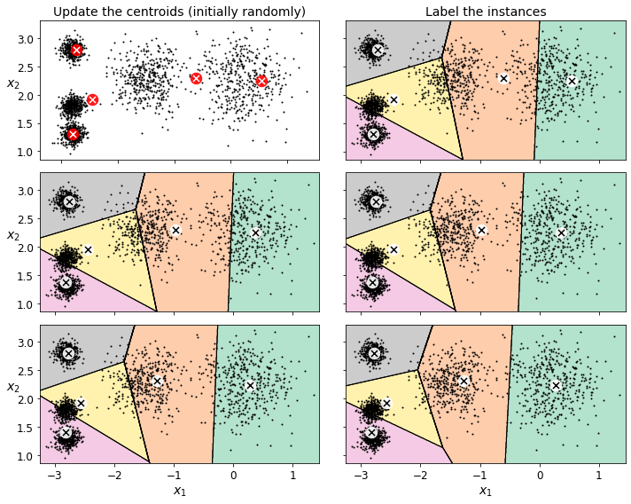

```python
plt.figure(figsize=(10, 8))

plt.subplot(321)
plot_data(X)
plot_centroids(kmeans_iter1.cluster_centers_, circle_color='r', cross_color='w')
plt.ylabel("$x_2$", fontsize=14, rotation=0)
plt.tick_params(labelbottom= False)
plt.title("Update the centroids (initially randomly)", fontsize=14)

plt.subplot(322)
plot_decision_boundaries(kmeans_iter1, X, show_xlabels=False, show_ylabels=False)
plt.title("Label the instances", fontsize=14)

plt.subplot(323)
plot_decision_boundaries(kmeans_iter1, X, show_centroids=False, show_xlabels=False)
plot_centroids(kmeans_iter2.cluster_centers_)

plt.subplot(324)
plot_decision_boundaries(kmeans_iter2, X, show_xlabels=False, show_ylabels=False)

plt.subplot(325)
plot_decision_boundaries(kmeans_iter2, X, show_centroids=False)
plot_centroids(kmeans_iter3.cluster_centers_)

plt.subplot(326)
plot_decision_boundaries(kmeans_iter3, X, show_ylabels=False)

save_fig("kmeans_algorithm_plot")
plt.show()
```

## K-Means Variability

```python
def plot_clusterer_comparison(clusterer1, clusterer2, X, title1=None, title2=None):
    clusterer1.fit(X)
    clusterer2.fit(X)

    plt.figure(figsize=(10, 3.2))

    plt.subplot(121)
    plot_decision_boundaries(clusterer1, X)
    if title1:
        plt.title(title1, fontsize=14)

    plt.subplot(122)
    plot_decision_boundaries(clusterer2, X, show_ylabels=False)
    if title2:
        plt.title(title2, fontsize=14)
```

```python
kmeans_rnd_init1 = KMeans(n_clusters=5, init="random", n_init=1,
                         algorithm="full", random_state=11)
kmeans_rnd_init2 = KMeans(n_clusters=5, init="random", n_init=1,
                         algorithm="full", random_state=19)
```

```
Saving figure kmeans_variability_plot
```

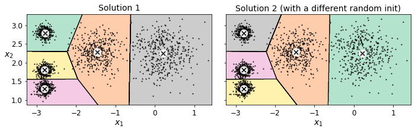

```python
plot_clusterer_comparison(kmeans_rnd_init1, kmeans_rnd_init2, X,
                          "Solution 1", "Solution 2 (with a different random init)")

save_fig("kmeans_variability_plot")
plt.show()
```

## Inertial

앞에서 말한 바와 같이 시작점이 달름에 따라 잘못된 지점으로 수렴할 수 있다. 그러면 우리가 돌린 k-means가 잘 됬는지 못 됬는지 평가하기 위해 평가방법이 필요한데, unsupervised learning이기 때문에 우리가 하던 바와 같이 MSE등의 방식을 통해 결과물과 비교할 수가 없다,

따라서 다른 방법이 필요한데, 여기서 나오는 Inertia metric이 바로 그런 방법이다.이는 각각의 instance와 centroid사이의 거리를 측정함으로써 얻을 수 있다.

```python
kmeans.inertia_
```

```
211.5985372581684
```

이는 각 instance와 가장 가까운 centroid의 거리의 제곱합

```python
X_dist = kmeans.transform(X)
np.sum(X_dist[np.arange(len(X_dist)), kmeans.labels_]**2)
```

```
211.59853725816856
```

```python
kmeans.score(X)
```

```
-211.59853725816856
```

## multiple initialization

```python
print(kmeans_rnd_init1.inertia_)
print(kmeans_rnd_init2.inertia_)
```

```
211.59853725816822
211.59853725816822
```

```python
kmeans_rnd_10_inits = KMeans(n_clusters=5, init="random", n_init=10,
                              algorithm="full", random_state=11)
kmeans10 = kmeans_rnd_10_inits.fit(X)
kmeans10
```

```
KMeans(algorithm='full', copy_x=True, init='random', max_iter=300, n_clusters=5,
       n_init=10, n_jobs=None, precompute_distances='auto', random_state=11,
       tol=0.0001, verbose=0)
```

```python
kmeans10.inertia_
```

```
211.59853725816822
```

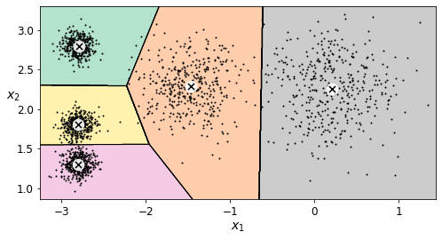

```python
plt.figure(figsize=(8, 4))
plot_decision_boundaries(kmeans_rnd_10_inits, X)
plt.show()
```

## K - means++

위와 같이 단순무식하게 시작점을 찾는 방법 대신 다음과 같은 방법을 사용하 수 있다.

1. (일단 아무 공간에나 중심점을 k개 찍고 시작하는 게 아니라) 가지고 있는 데이터 포인트 중에서 무작위로 1개를 선택하여 그 녀석을 첫번째 중심점으로 지정한다.
2. 나머지 데이터 포인트들에 대해 그 첫번째 중심점까지의 거리를 계산한다.
3. 두번째 중심점은 각 점들로부터 거리비례 확률에 따라 선택한다. (뭔 소리야?) 즉, 이미 지정된 중심점으로부터 최대한 먼 곳에 배치된 데이터포인트를 그 다음 중심점으로 지정한다는 뜻이다.
4. 중심점이 k개가 될 때까지 2, 3번을 반복한다.

이를 코드로 사용하는 방법은 KMeans( init = "k-means++")를 사용하면 된다. 근데 사실은 이게 default 값

```python
KMeans()
```

```
KMeans(algorithm='auto', copy_x=True, init='k-means++', max_iter=300,
       n_clusters=8, n_init=10, n_jobs=None, precompute_distances='auto',
       random_state=None, tol=0.0001, verbose=0)
```

```python
good_init = np.array([[-3, 3], [-3, 2], [-3, 1], [-1, 2], [0, 2]])
kmeans = KMeans(n_clusters=5, init=good_init, n_init=1, random_state=42)
kmeans.fit(X)
kmeans.inertia_
```

```
211.5985372581684
```

## Accerlerated K-Means

K-Means 방법은 계산량이 매우 많다. 따라서 필요 없는 계산을 버림으로써 속도를 늘릴 수 있는데, 삼각 부등식을 사용하고 (점 A,B,D 가 주어져 있을 때 AC <= AB + BC) 점과 중심 사이의 거리의 상한선과 하한선을 계속 추적함으로써 ?? 시간을 줄일 수 있다고 합니다.(무슨소리인지 모르겠습니다.)

KMeans(algorithm = "elkan")으로 사용 가능한데, sparse data에서는 적용되지 않아서 sparse 인 경우에는 full을 쓰고 dense한 경우에만 적용되는 방식으로 진행된다고 합니다.

```python
%timeit KMeans(algorithm="elkan").fit(X)
```

```
10 loops, best of 3: 85.6 ms per loop
```

```python
%timeit KMeans(algorithm="full").fit(X)
```

```
10 loops, best of 3: 126 ms per loop
```

## Mini - Batch K- Means

K-평균 방법에서는 중심위치와 모든 데이터 사이의 거리를 계산해야 하기 때문에 데이터의 갯수가 많아지면 계산량도 늘어단다. 데이터의 수가 너무 많을 때는 미니배치 K-평균(Mini-batch) 군집화 방법을 사용하면 계산량을 줄일 수 있다. 미니배치 K-평균 군집화는 데이터를 미니배치 크기만큼 무작위로 분리하여 K-평균 군집화를 한다. 모든 데이터를 한꺼번에 썼을 때와 결과가 다를 수는 있지만 큰 차이가 없다.

```python
from sklearn.cluster import MiniBatchKMeans
```

```python
minibatch_kmeans = MiniBatchKMeans(n_clusters = 5, random_state = 42)
minibatch_kmeans.fit(X)
```

```
MiniBatchKMeans(batch_size=100, compute_labels=True, init='k-means++',
                init_size=None, max_iter=100, max_no_improvement=10,
                n_clusters=5, n_init=3, random_state=42,
                reassignment_ratio=0.01, tol=0.0, verbose=0)
```

```python
print(minibatch_kmeans.inertia_)
print(kmeans.inertia_)
```

```
211.93186531476775
211.5985372581684
```

DATA가 너무 커서 memmap 를 못 써서, 제시된 다른 방법 사용

```python
def load_next_batch(batch_size):
    return X[np.random.choice(len(X), batch_size, replace=False)]
```

```python
np.random.seed(42)
```

```python
k = 5
n_init = 10
n_iterations = 100
batch_size = 100
init_size = 500  # more data for K-Means++ initialization
evaluate_on_last_n_iters = 10

best_kmeans = None

for init in range(n_init):
    minibatch_kmeans = MiniBatchKMeans(n_clusters=k, init_size=init_size)
    X_init = load_next_batch(init_size)
    minibatch_kmeans.partial_fit(X_init)

    minibatch_kmeans.sum_inertia_ = 0
    for iteration in range(n_iterations):
        X_batch = load_next_batch(batch_size)
        minibatch_kmeans.partial_fit(X_batch)
        if iteration >= n_iterations - evaluate_on_last_n_iters:
            minibatch_kmeans.sum_inertia_ += minibatch_kmeans.inertia_

    if (best_kmeans is None or
        minibatch_kmeans.sum_inertia_ < best_kmeans.sum_inertia_):
        best_kmeans = minibatch_kmeans
```

```python
best_kmeans.score(X)
```

```
-211.70999744411483
```

```python
%timeit KMeans(n_clusters=5).fit(X)
```

```
10 loops, best of 3: 49.4 ms per loop
```

```python
%timeit MiniBatchKMeans(n_clusters=5).fit(X)
```

```
10 loops, best of 3: 28.8 ms per loop
```

기본적으로, minibatch가 일반 kmeans보다 더 빠르지만 정확도는 더 낮고, 이 경향은 k가 커지면서 심화된다. 그래프로 그려보자.

```python
from timeit import timeit
```

```python
times = np.empty((100, 2))
inertias = np.empty((100, 2))
for k in range(1, 101):
    kmeans_ = KMeans(n_clusters=k, random_state=42)
    minibatch_kmeans = MiniBatchKMeans(n_clusters=k, random_state=42)
    print("\r{}/{}".format(k, 100), end="")
    times[k-1, 0] = timeit("kmeans_.fit(X)", number=10, globals=globals())
    times[k-1, 1]  = timeit("minibatch_kmeans.fit(X)", number=10, globals=globals())
    inertias[k-1, 0] = kmeans_.inertia_
    inertias[k-1, 1] = minibatch_kmeans.inertia_
```

```
100/100
```

```
Saving figure minibatch_kmeans_vs_kmeans
```

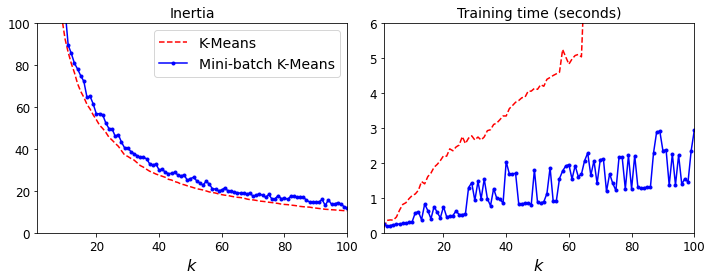

```python
plt.figure(figsize=(10,4))

plt.subplot(121)
plt.plot(range(1, 101), inertias[:, 0], "r--", label="K-Means")
plt.plot(range(1, 101), inertias[:, 1], "b.-", label="Mini-batch K-Means")
plt.xlabel("$k$", fontsize=16)
plt.title("Inertia", fontsize=14)
plt.legend(fontsize=14)
plt.axis([1, 100, 0, 100])

plt.subplot(122)
plt.plot(range(1, 101), times[:, 0], "r--", label="K-Means")
plt.plot(range(1, 101), times[:, 1], "b.-", label="Mini-batch K-Means")
plt.xlabel("$k$", fontsize=16)
plt.title("Training time (seconds)", fontsize=14)
plt.axis([1, 100, 0, 6])

save_fig("minibatch_kmeans_vs_kmeans")
plt.show()
```

## Finding the optimal number of cluster

```
Saving figure bad_n_clusters_plot
```

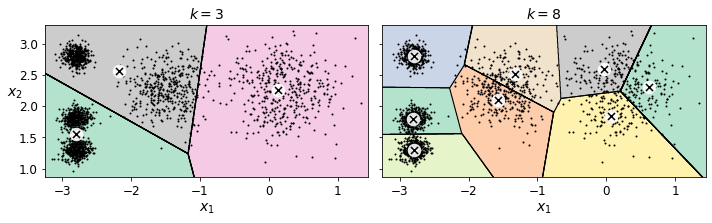

```python
kmeans_k3 = KMeans(n_clusters=3, random_state=42)
kmeans_k8 = KMeans(n_clusters=8, random_state=42)

plot_clusterer_comparison(kmeans_k3, kmeans_k8, X, "$k=3$", "$k=8$")
save_fig("bad_n_clusters_plot")
plt.show()
```

```python
print(kmeans_k3.inertia_)
print(kmeans_k8.inertia_)
```

```
653.2167190021553
118.41983763508077
```

k가 커지면 inertia가 매우 작아지지만, 이는 의미가 없다. 상식적으로 class가 많아질 수록 각 점과 어떤 class 의 중심 사이의 거리가 가까워 질 것이기 때문에.

```python
kmeans_per_k = [KMeans(n_clusters=k, random_state=42).fit(X)
                for k in range(1, 10)]
inertias = [model.inertia_ for model in kmeans_per_k]
```

```
Saving figure inertia_vs_k_plot
```

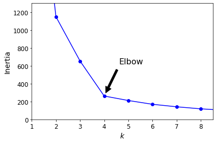

```python
plt.plot(range(1, 10), inertias, "bo-")
plt.xlabel("$k$", fontsize=14)
plt.ylabel("Inertia", fontsize=14)
plt.annotate('Elbow',
             xy=(4, inertias[3]),
             xytext=(0.55, 0.55),
             textcoords='figure fraction',
             fontsize=16,
             arrowprops=dict(facecolor='black', shrink=0.1)
            )
plt.axis([1, 8.5, 0, 1300])
save_fig("inertia_vs_k_plot")
plt.show()
```

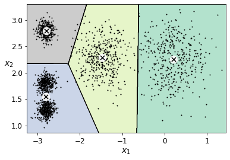

```python
plot_decision_boundaries(kmeans_per_k[3], X)
plt.show()
```

또 다른 방법은 silhouette score를 확인하는 것. silhouette score는 mean silhouette coefficient의 평균이다.

silhouettet coefficient는 (b-a)/max(a,b) 로 나타나는데, a는 같은 cluster에 들어가는 점들과의 평균 거리이고, b는 가장 가까운 클러스터의 점들과의 평균거리이다. score가 1이면 a가 b에 비해 충분히 작으니 제대로 된 거고, -1이면 이상한 cluster에 들어가 있다는 뜻이다. a에 가까우면 a와 b가 차이가 안난다는 뜻이니까 boundary 근처에 위치해서 저쪽 클러스터나 이쪽 클러스터나 그 평균값이 차이가 별로 안난다는 뜻.

```python
from sklearn.metrics import silhouette_score
```

```python
silhouette_score(X, kmeans.labels_)
```

```
0.655517642572828
```

```python
silhouette_scores = [silhouette_score(X, model.labels_)
                     for model in kmeans_per_k[1:]]
```

```
Saving figure silhouette_score_vs_k_plot
```

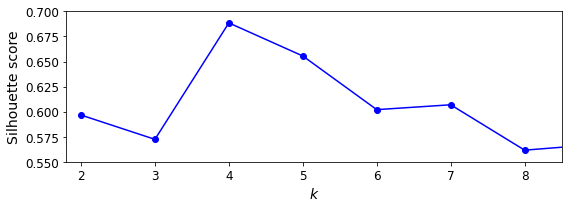

```python
plt.figure(figsize=(8, 3))
plt.plot(range(2, 10), silhouette_scores, "bo-")
plt.xlabel("$k$", fontsize=14)
plt.ylabel("Silhouette score", fontsize=14)
plt.axis([1.8, 8.5, 0.55, 0.7])
save_fig("silhouette_score_vs_k_plot")
plt.show()
```

위의 실루엣 스코어를 보면, k=5 역시 k=4보다 부적절하긴 하지만 제법 괜찮은 걸 알 수 있다.

또 다른 방법은 각 cluster 마다 그 평균 실루엣 스코어를 구해서 나타내는것. silhouette diagram이라고 한다.

```
Saving figure silhouette_analysis_plot
```

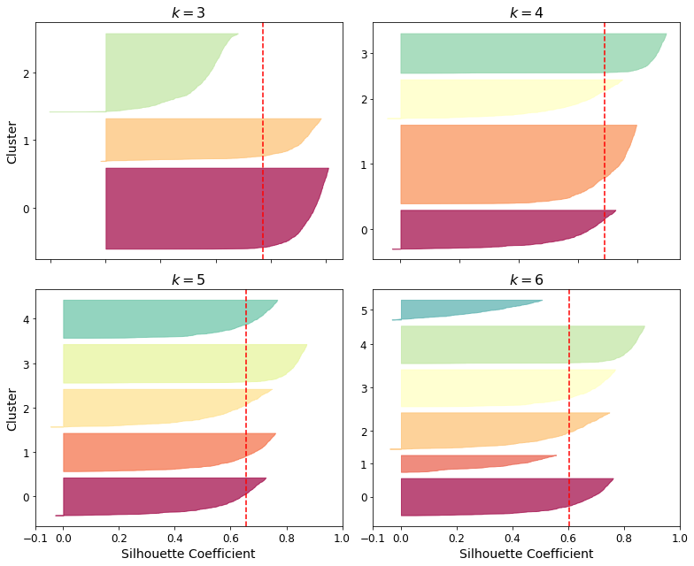

```python
from sklearn.metrics import silhouette_samples
from matplotlib.ticker import FixedLocator, FixedFormatter

plt.figure(figsize=(11, 9))

for k in (3, 4, 5, 6):
    plt.subplot(2, 2, k - 2)

    y_pred = kmeans_per_k[k - 1].labels_
    silhouette_coefficients = silhouette_samples(X, y_pred)

    padding = len(X) // 30
    pos = padding
    ticks = []
    for i in range(k):
        coeffs = silhouette_coefficients[y_pred == i]
        coeffs.sort()

        color = mpl.cm.Spectral(i / k)
        plt.fill_betweenx(np.arange(pos, pos + len(coeffs)), 0, coeffs,
                          facecolor=color, edgecolor=color, alpha=0.7)
        ticks.append(pos + len(coeffs) // 2)
        pos += len(coeffs) + padding

    plt.gca().yaxis.set_major_locator(FixedLocator(ticks))
    plt.gca().yaxis.set_major_formatter(FixedFormatter(range(k)))
    if k in (3, 5):
        plt.ylabel("Cluster")

    if k in (5, 6):
        plt.gca().set_xticks([-0.1, 0, 0.2, 0.4, 0.6, 0.8, 1])
        plt.xlabel("Silhouette Coefficient")
    else:
        plt.tick_params(labelbottom=False)

    plt.axvline(x=silhouette_scores[k - 2], color="red", linestyle="--")
    plt.title("$k={}$".format(k), fontsize=16)

save_fig("silhouette_analysis_plot")
plt.show()
```

## Limits of KMeans

KMeans 는 각 클러스터의 사이즈,밀도가 각각 다르고, 클러스터의 형태가 원형이 아니면 정확도가 낮아진다.

```python
X1, y1 = make_blobs(n_samples=1000, centers=((4, -4), (0, 0)), random_state=42)
X1 = X1.dot(np.array([[0.374, 0.95], [0.732, 0.598]]))
X2, y2 = make_blobs(n_samples=250, centers=1, random_state=42)
X2 = X2 + [6, -8]
X = np.r_[X1, X2]
y = np.r_[y1, y2]
```

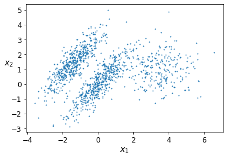

```python
plot_clusters(X)
```

```python
kmeans_good = KMeans(n_clusters=3, init=np.array([[-1.5, 2.5], [0.5, 0], [4, 0]]), n_init=1, random_state=42)
kmeans_bad = KMeans(n_clusters=3, random_state=42)
kmeans_good.fit(X)
kmeans_bad.fit(X)
```

```
KMeans(algorithm='auto', copy_x=True, init='k-means++', max_iter=300,
       n_clusters=3, n_init=10, n_jobs=None, precompute_distances='auto',
       random_state=42, tol=0.0001, verbose=0)
```

```
Saving figure bad_kmeans_plot
```

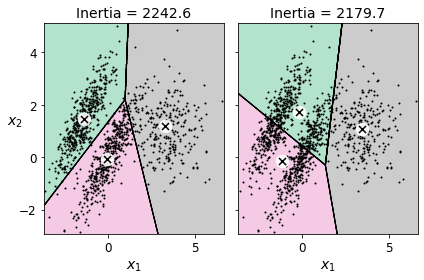

```python
plt.subplot(121)
plot_decision_boundaries(kmeans_good, X)
plt.title("Inertia = {:.1f}".format(kmeans_good.inertia_), fontsize=14)

plt.subplot(122)
plot_decision_boundaries(kmeans_bad, X, show_ylabels=False)
plt.title("Inertia = {:.1f}".format(kmeans_bad.inertia_), fontsize=14)

save_fig("bad_kmeans_plot")
plt.show()
```

## using clustering for image segmentation

```python
import urllib.request
# Download the ladybug image
images_path = os.path.join(PROJECT_ROOT_DIR, "images", "unsupervised_learning")
os.makedirs(images_path, exist_ok=True)
DOWNLOAD_ROOT = "https://raw.githubusercontent.com/ageron/handson-ml2/master/"
filename = "ladybug.png"
print("Downloading", filename)
url = DOWNLOAD_ROOT + "images/unsupervised_learning/" + filename
urllib.request.urlretrieve(url, os.path.join(images_path, filename))
```

```
Downloading ladybug.png
```

```
('./images/unsupervised_learning/ladybug.png',
 <http.client.HTTPMessage at 0x7f94d8d810f0>)
```

```python
from matplotlib.image import imread
image = imread(os.path.join(images_path, filename))
image.shape
```

```
(533, 800, 3)
```

Image data는 3d array로, 첫 항이 높이, 두번째 항이 넓이, 세번째 항이 색깔의 범주를 나타낸다. 여기서는 세번째 항이 RED, GREEN, BLUE로 나타난다. 즉, 각 픽셀마다 rgb의 3개의 데이터를 가지며, 이 3개의 데이터를 kmeans로 분류하여 픽셀의 색이 무엇인지 판단한다.

```python
X = image.reshape(-1, 3)
kmeans = KMeans(n_clusters=8, random_state=42).fit(X)
segmented_img = kmeans.cluster_centers_[kmeans.labels_]
segmented_img = segmented_img.reshape(image.shape)
```

```python
segmented_imgs = []
n_colors = (10, 8, 6, 4, 2)
for n_clusters in n_colors:
    kmeans = KMeans(n_clusters=n_clusters, random_state=42).fit(X)
    segmented_img = kmeans.cluster_centers_[kmeans.labels_]
    segmented_imgs.append(segmented_img.reshape(image.shape))
```

```
Saving figure image_segmentation_diagram
```

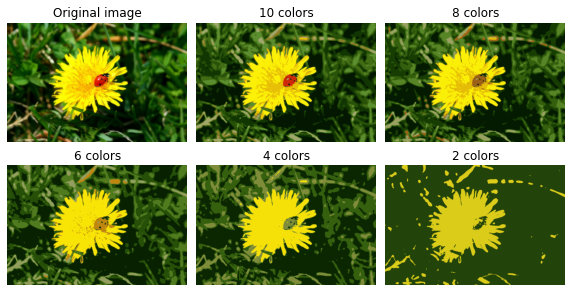

```python
plt.figure(figsize=(10,5))
plt.subplots_adjust(wspace=0.05, hspace=0.1)

plt.subplot(231)
plt.imshow(image)
plt.title("Original image")
plt.axis('off')

for idx, n_clusters in enumerate(n_colors):
    plt.subplot(232 + idx)
    plt.imshow(segmented_imgs[idx])
    plt.title("{} colors".format(n_clusters))
    plt.axis('off')

save_fig('image_segmentation_diagram', tight_layout=False)
plt.show()
```